# Lab3

1512005

23 October 2017

Load in Data.

```r
voting <- read.csv("GE-referendum-and-census.csv")
voting <- voting[!(voting$region %in% c("Wales", "Scotland")),]
```

Create dataset of allocated region.

```r
my_region <- voting$region[voting$pano == 252] #252  Finchley & Golders Green
my_region
```

```
## [1] London
## 11 Levels: East Midlands Eastern London North East North West ... Yorkshire and the Humber
```

```r
my_subset <- voting[voting$region == "London", ]

ld.change <- with(my_subset, (ld17/total17)/(ld15/total15)) #libdem voteshare in 2017 / voteshare in 2015
leave <- my_subset$leave16sh #estimated leave vote in constituency
```

Load packages dplyr and ggplot2.

```r
library(dplyr)
library(ggplot2)
```

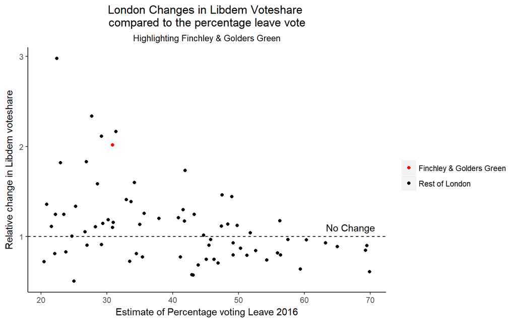

```r
my_constituency <- ifelse((my_subset$pano)==252, "Finchley & Golders Green", "Rest of London")
my_plot0 <- my_subset %>% ggplot(aes(x = leave, y= ld.change, color = my_constituency))
my_plot1 <- my_plot0 + geom_point()

my_plot2 <- my_plot1 + scale_colour_manual(name="", values = c("Finchley & Golders Green" = "red", "Rest of London" = "black")) + xlab("Estimate of Percentage voting Leave 2016") + ylab("Relative change in Libdem voteshare") + ggtitle("London Changes in Libdem Voteshare \ncompared to the percentage leave vote", subtitle = "Highlighting Finchley & Golders Green") + geom_hline(yintercept =1, linetype = "dashed") + annotate("text", x = 67, y = 1.10, label = "No Change") + theme(panel.grid.major = element_blank(), panel.grid.minor = element_blank(),
panel.background = element_blank(), axis.line = element_line(colour = "black"), plot.title = element_text(hjust = 0.5), plot.subtitle = element_text(hjust = 0.5))
print(my_plot2)
```

This plot shows the change in Liberal Democrat voteshare between the 2015 and 2017 general elections, compared to the estimated percentage of people who voted leave in a particular constituency. The plot shows all constituencies in London.  
This map should be somewhat interesting given the Liberal Democrats flagship policy of another referendum on brexit, and that London was the most remain area in the country.  
While there does appear to be many constituencies which icreased in libdem voteshare and had a low leave vote, and vice versa, this is definitely not the rule. In fact places with less than 30% leave vote still had reduced libdem voteshare.  
One has to imagine if the rising of libdem voteshare is just reversion to the mean, given the particularly bad results for them in 2015.

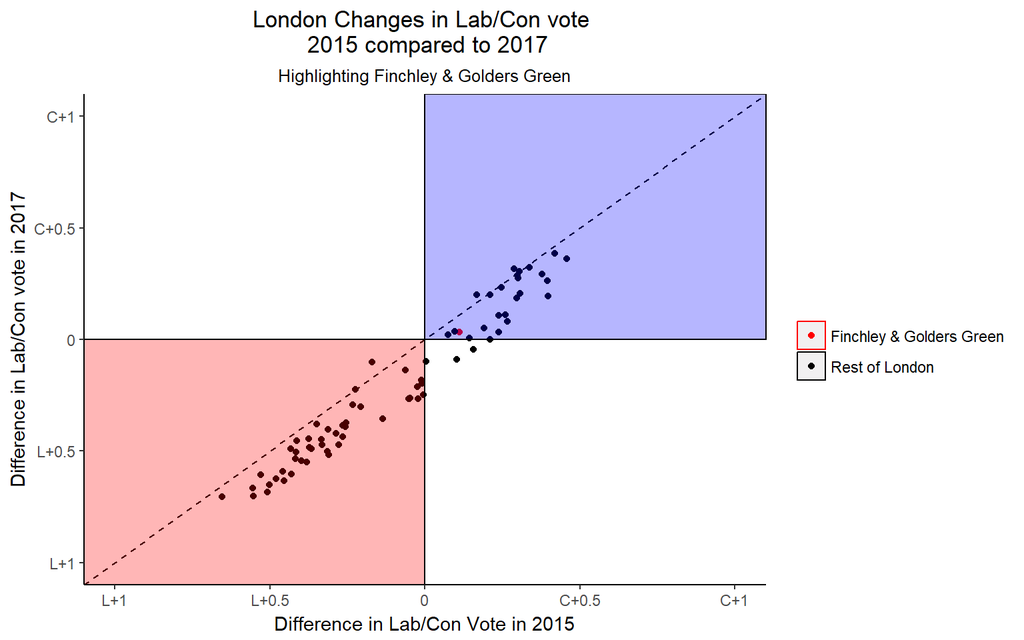

```r
my_subset$labcondif17 <- my_subset$con17 - my_subset$lab17    #difference between con votes and labour votes 2017
my_subset$labcondif17 <- my_subset$labcondif17/my_subset$total17 # % difference between con and labour votes 2017

my_subset$labcondif15 <- my_subset$con15 - my_subset$lab15   #similar to above
my_subset$labcondif15 <- my_subset$labcondif15/my_subset$total15


lcd0 <- my_subset %>% ggplot(aes(x = labcondif15, y= labcondif17, color = my_constituency))
lcd1 <- lcd0 + geom_point()

lcd2 <- lcd1 + scale_colour_manual(name="", values = c("Finchley & Golders Green" = "red", "Rest of London" = "black")) + xlab("Difference in Lab/Con Vote in 2015") + ylab("Difference in Lab/Con vote in 2017") + ggtitle("London Changes in Lab/Con vote \n 2015 compared to 2017", subtitle = "Highlighting Finchley & Golders Green") + geom_abline(intercept = 0,linetype = "dashed") + theme(panel.grid.major = element_blank(), panel.grid.minor = element_blank(),
panel.background = element_blank(), axis.line = element_line(colour = "black"), plot.title = element_text(hjust = 0.5), plot.subtitle = element_text(hjust = 0.5)) +geom_vline(xintercept = 0)+geom_hline(yintercept = 0) + scale_x_continuous(breaks = seq(-1,1,0.5),labels=c("L+1","L+0.5","0", "C+0.5", "C+1"), limits = c(-1,1))+scale_y_continuous(breaks = seq(-1,1,0.5), labels=c("L+1","L+0.5","0", "C+0.5", "C+1"), limits = c(-1,1))+
  geom_rect(xmin = -Inf, xmax = 0,   ymin = -Inf, ymax = 0,   fill = "red", alpha = 0.0031) +
  geom_rect(xmin = 0,    xmax = Inf, ymin = 0, ymax = Inf,   fill = "blue", alpha = 0.0031)

print(lcd2)
```

This graph provides information on the differences between Labour and Conservative votes in a particular London constituency. It should be noted the performance of other parties are not considered, and that this does not mean voters are switching directly from Labour/Conservative or vice versa. Points below the line indicate that Labour improved their performance against the Conservatives, while above the line is the opposite. Those in the red square were Labour in both 2015 and 2017, those in blue the same but for Conservative. Those in the bottom right square changed their relative votes from Conservative to Labour in 2017.  
It shows that for the vast majority of London constituencies, Labour gained votes relative to the Conservatives in 2017, with 3 constituencies changing from having more Conservative votes to more Labour votes.  
Again, note this does not mean the constituencies elected Con or Labour MPs, just how they performed relative to eachother.  
The constituency almost directly on the horizontal line is Kensington, which DID change from Conservative to Labour in 2017, with only 20 votes difference.